# ANOVA5: Within-Subjects

Tehran Davis

11/20/2017

Note that this weeks vignette requires the following packages in `R`- `tidyverse`, `plyr`, `afex`, `multcomp`, `multcompView`, `Rmisc`:

```r
pacman::p_load(tidyverse, plyr, afex, multcomp,multcompView, Rmisc)
```

# Within-Subject v. Between Subjects

This week we more onto within-subjects designs. As we mentioned in class we have a within-subject design whenever data from the same participants exists on at least two levels of a factor (or analogously occupied at least two cells within our interaction matrix). Up until now we have considered ANOVA in between subjects designs. Data at each level of each factor comes from a different set of participants. For example, our favorite data set:

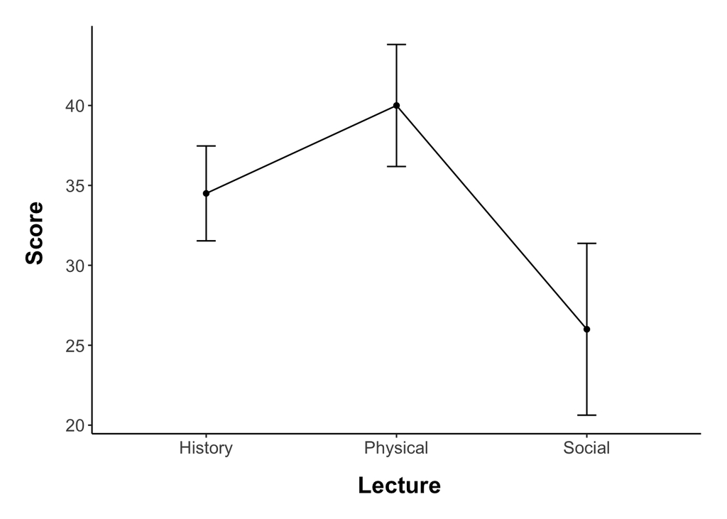

```r
example1_data <- read.table("https://raw.githubusercontent.com/tehjespah/tehjespah.github.io/master/teaching/PSYC7014/datasets/ANOVA5_example2.txt", header=T)

# summary(example1_data)

## plotting:

# need to make the appropriate corrections for error bars on repeated measures designs:
normedData <- Rmisc::normDataWithin(data = example1_data,measurevar = "Score",idvar = "Subject")
nWithinGroups <- nlevels(example1_data$Lecture)
correctionFactor <- sqrt(nWithinGroups/(nWithinGroups - 1))


p <- ggplot(example1_data,mapping = aes(x = Lecture,y = Score, group=1)) +
  stat_summary(data = normedData,width=0.1, geom = "errorbar",fun.data = "mean_se", fun.args = list(mult = correctionFactor)) +
  stat_summary(geom = "point",fun.y = "mean") +
  stat_summary(geom = "line", fun.y="mean") + theme_classic() +
  #stat_summary(aes(label=..y..), fun.data="mean_se", geom="text", size=2) +
  theme(
    axis.title = element_text(size = 16, face = "bold", lineheight = .55),
    axis.text = element_text(size = 12),
    legend.title = element_text(size = 12, face = "bold"),
    legend.position = c(.25,.25)) +
  scale_color_manual(values=c("black","grey50")) +
  xlab("\n Lecture") +
  ylab ("Score \n") +
  theme(plot.margin=unit(c(.25,.25,.25,.25),"in")) +

  # stack legend boxes horizontally:
  theme(legend.box = "horizontal")

show(p)
```

Before we might have treated this as a between subjects design. Running the BS ANOVA:

```r
# create between subject IDs:

example1_data$BSubjects <- 1:nrow(example1_data)

between.aov <- afex::aov_ez(id = "BSubjects", dv = "Score", data = example1_data,between = "Lecture",type = 3, return = "afex_aov", anova_table=list(es = "pes", sig_symbols = rep("", 4)))
```

```
## Contrasts set to contr.sum for the following variables: Lecture
```

```r
show(between.aov)
```

```
## Anova Table (Type 3 tests)
##
## Response: Score
##    Effect    df    MSE    F pes p.value
## 1 Lecture 2, 33 139.36 4.28 .21     .02
```

However, let’s assume instead that this data set comes a within design. That is, instead of different participants in each Lecture group, the same group of people went through all three lectures:

[output not shown]

In both of these cases the data is exactly the same. What has changed is how we parse the variance (you’ll notice that the denominator degrees of freedom are different for the second ANOVA). In a within design, we need to take into account the “within-subject” variance. That is how individual subjects vary from one level of treatment to the other. In this respect, within designs are typically more powerful than analogous between designs. WhiletThe inherent differences between individual subjects is present in both types of designs, your within-subjects ANOVA model includes it in its analysis. This increase in power is reflected by the lower MSE (48.52 v. 139.36) and subsequently, larger F-value (12.31 v. 4.28) and effect size (0.53 v. 0.21) in our within-subjects analysis.

Well if that’s the case why not run within-subject (WS) designs all of the time. Well, typically psychologists do when the phenomena lends itself to WS-designs. BUT there are certainly times when they are not practical, for example if you are concerned about learning, practice, or carryover effects where exposure to a treatment on one level might impact the other levels. For example if you were studying radiation poisoning and had a placebo v. radiation dose condition, it be likely that you wouldn’t run your experiement as a within—or at the very least you wouldn’t give them the radiation first. It would also be likely that you’d be in violation several standards of ethics.

Perhaps a little more inside baseball, there are underlying questions on whether or not we are indeed making the appropriate corrections in our WS models or correctly specifying our experiments units. For example, if participants data is collected over 4 (or any number) trials in each treactment condition, then both SPSS and R `afex` require you to collapse those trials to means, therefore turning what are truly 4 observations into 1 see [Ludo et al., 1999](https://search.proquest.com/docview/232357509/fulltextPDF/E6BE3DC885B947D6PQ/) for details. In R, `afex` handles this automatically for data in long format. In SPSS you need to organize your data in another program (like Excel), calculate the means, and then send that data to SPSS.

At the same time there are debates as to the importance of asphericity in the subjects data. One alternative method that avoids these issues is to invoke mixed models (e.g., `lmer`). However, if you really want to go down the rabbit hole check out [Doug Bates reponse on appropriate dfs and p.values in `lmer`](https://stat.ethz.ch/pipermail/r-help/2006-May/094765.html). You’ll not that these discussions were ten years ago and are still being debated (see [here](https://www.reddit.com/r/AskStatistics/comments/2x9ipp/linear_mixed_effect_models_and_pvalues_r/).

For now, we won’t go down the rabbit hole and just focus on the practical issues confreonted when running a repeated-measures ANOVA.

# EXAMPLE 1

To start, we will use data from Howell’s example in the opening of Chapter 14. Here are data related to the effectiveness of relaxation therapy to the number of episodes that chronic migraine sufferers reported. Data was collected from each subject over the course of 5 weeks. After week 2 the therapy treatment was implemented effectively dividing the 5 weeks into two phases, Pre (Weeks 1 & 2) and Post (Weeks 3,4, & 5).

## loading in the data:

```r
example1_long <- gather(example1,key = "Week",value = "Migraines", 2:6)

example1_long$Week <- as.factor(example1_long$Week)

example1_long
```

| Subject | Week | Migraines |
| --- | --- | --- |
| 1 | Wk1 | 21 |
| 2 | Wk1 | 20 |
| 3 | Wk1 | 17 |
| 4 | Wk1 | 25 |
| 5 | Wk1 | 30 |
| 6 | Wk1 | 19 |
| 7 | Wk1 | 26 |
| 8 | Wk1 | 17 |
| 9 | Wk1 | 26 |
| 1 | Wk2 | 22 |

[output cut: 35 more lines]

Now each Subject × Week observation is on a single row.

## plotting the data

One additional concern that we must deal with when plotting within-subjects data is the error bars. Plotting the standard error or regular confidence intervals may be misleading for making statistical inferences. This is beause the values, normally caluculated do not account for within subject correlation. Luckily for us there is a correction that we can make using the `Rmisc` package. Please see [Cousineau (2005)](https://doaj.org/article/dd17c4ccc4684c9da60c02f3864d09e6) and [Morey (2008)](https://doaj.org/article/011cd52c58b449c4bf169676ca704062) for details on this issue and subseuent correction.

The practical steps for this correction include first norming the data. The function `Rmisc::normDataWithin()` normalizes each subject (identified by `idvar`) so that they have the same mean and obtaining the selected measure from normed data. **(note that for mixed ANOVA designs, within-subjects are members of seperate between groups, within each group specified by `betweenvars`, here we have a purely within design, so `betweenvars` is `NULL`)

```r
normedData <- Rmisc::normDataWithin(data = example1_long,measurevar = "Migraines",idvar = "Subject", betweenvars = NULL)

normedData
```

| Subject | Week | Migraines | MigrainesNormed |
| --- | --- | --- | --- |
| 1 | Wk1 | 21 | 21.644444 |
| 1 | Wk4 | 6 | 6.644444 |
| 1 | Wk5 | 6 | 6.644444 |
| 1 | Wk3 | 8 | 8.644444 |
| 1 | Wk2 | 22 | 22.644444 |
| 2 | Wk5 | 4 | 5.844444 |
| 2 | Wk4 | 4 | 5.844444 |
| 2 | Wk2 | 19 | 20.844444 |
| 2 | Wk3 | 10 | 11.844444 |
| 2 | Wk1 | 20 | 21.844444 |

[output cut: 35 more lines]

One final step is to make a correction on these values ([Morey (2008)](https://doaj.org/article/011cd52c58b449c4bf169676ca704062)). This is done by taking the number of levels of the within factor (`nWithinGroups`) and applying the following:

```r
# get the number of levels in Week:
nWithinGroups <- nlevels(example1_long$Week)

# apply the correction factor:
correctionFactor <- sqrt(nWithinGroups/(nWithinGroups - 1))
```

Our `normedData` se, sd, and ci values are then multiplied by this `correctionFactor`.

Once we have each of these we can create our `errorbars` using `stat_summary()`. Note that if you choose to make a line plot, it’s much easier to create your points and errorbars seperately, rather than use the “pointrange”. You use the `normedData` for your errorbars and the rawdata for everything else:

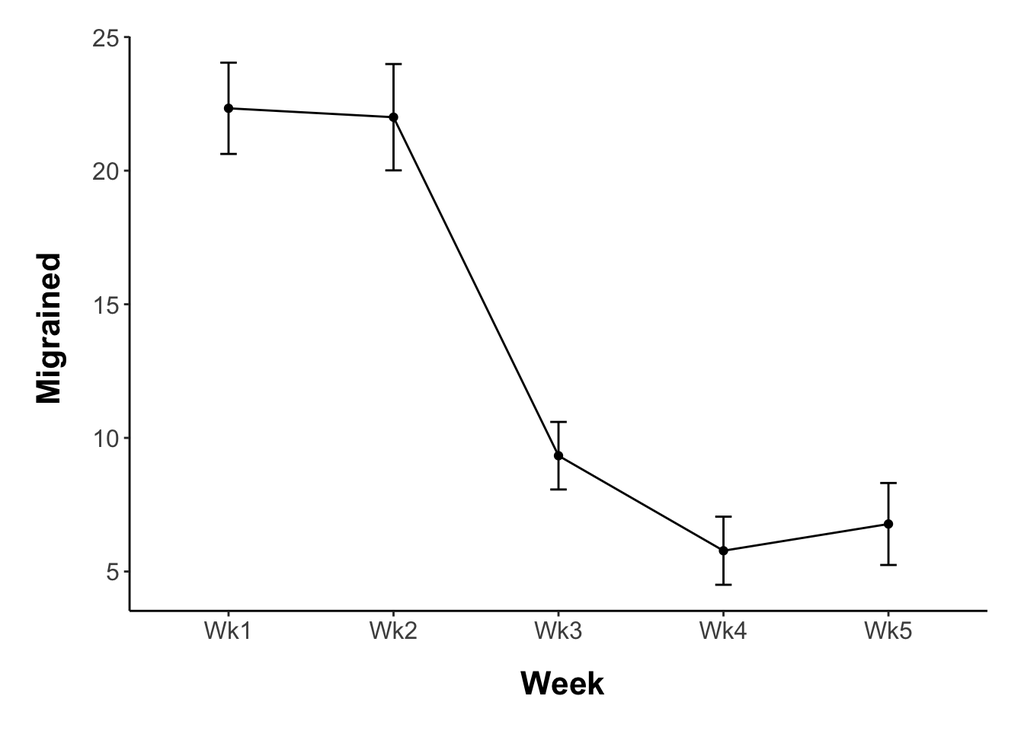

```r
p <- ggplot(example1_long,mapping = aes(x = Week,y = Migraines, group=1)) +

  # note that here I am creating the errorbars using the normedData and applying the correction factor:

  stat_summary(data = normedData,width=0.1, geom = "errorbar",fun.data = "mean_se", fun.args = list(mult = correctionFactor)) +

  # and here I am using the raw data to plot my points:

  stat_summary(geom = "point",fun.y = "mean") +
  stat_summary(geom = "line", fun.y="mean") + theme_classic() +
  #stat_summary(aes(label=..y..), fun.data="mean_se", geom="text", size=2) +
  theme(
    axis.title = element_text(size = 16, face = "bold", lineheight = .55),
    axis.text = element_text(size = 12),
    legend.title = element_text(size = 12, face = "bold"),
    legend.position = c(.25,.25)) +
  scale_color_manual(values=c("black","grey50")) +
  xlab("\n Week") +
  ylab ("Migrained \n") +
  theme(plot.margin=unit(c(.25,.25,.25,.25),"in")) +

  # stack legend boxes horizontally:
  theme(legend.box = "horizontal")

show(p)
```

## running a within ANOVA (afex):

Running a WS ANOVA is just like running a BS ANOVA in `afex`. We call in our within subjects factors using the `within=` argument.

```r
within.aov <- afex::aov_ez(id = "Subject", dv = "Migraines", data = example1_long,between = NULL,within = "Week",type = 3, return = "afex_aov", anova_table=list(es = "pes", sig_symbols = rep("", 4), correction="none"))
within.aov
```

```
## Anova Table (Type 3 tests)
##
## Response: Migraines
##   Effect    df  MSE     F pes p.value
## 1   Week 4, 32 7.20 85.04 .91  <.0001
```

You’ll also notice in the code above that I’ve added a correction=“none” call to my `anova_table` argument. Otherwise `afex` defaults to applying the Greenhouse-Geisser correction [link](https://statistics.laerd.com/statistical-guides/sphericity-statistical-guide.php). There is an argument to be made that you should always make a correction to guard against deviations from sphericity. The correction becomes larger the further your data is from sphericity. However, standard practice in the psychology literature is to only apply the correction if our data fail Mauchly’s Test [link](https://statistics.laerd.com/statistical-guides/sphericity-statistical-guide.php). The outcome of this test can be obtained by using the `summary()` function

```r
summary(within.aov)
```

```
##
## Univariate Type III Repeated-Measures ANOVA Assuming Sphericity
##
##                 SS num Df Error SS den Df       F    Pr(>F)
## (Intercept) 7893.7      1   486.71      8 129.747 3.186e-06 ***
## Week        2449.2      4   230.40     32  85.042 < 2.2e-16 ***
## ---
## Signif. codes:  0 '***' 0.001 '**' 0.01 '*' 0.05 '.' 0.1 ' ' 1
##
##
## Mauchly Tests for Sphericity
##
##      Test statistic p-value
## Week        0.28236 0.53699
##
##
## Greenhouse-Geisser and Huynh-Feldt Corrections
##  for Departure from Sphericity
##
##       GG eps Pr(>F[GG])
## Week 0.68446  5.773e-12 ***
## ---
## Signif. codes:  0 '***' 0.001 '**' 0.01 '*' 0.05 '.' 0.1 ' ' 1
##
##        HF eps  Pr(>F[HF])
## Week 1.075624 1.39444e-16
```

This gives us our original ANOVA, the Mauchly Test-in this case p>.05 so no correction necessary- and the Greenhouse-Geisser and Huynh-Feldt corrections. If your elect to make the correction (i.e., the data fails Mauchly’s Test) then you could multiply your original degrees of freedom by the GG eps (or HF eps). The p.value next to the correction values tells you the p.value for your ANOVA effect assuming corrections. In this case even with the corrections the effect of Week is significant. Alternatively you could just rerun the `afex` function and specifying the `correction=` call.

```r
## GG correction:
within.aov <- afex::aov_ez(id = "Subject", dv = "Migraines", data = example1_long,between = NULL,within = "Week",type = 3, return = "afex_aov", anova_table=list(es = "pes", sig_symbols = rep("", 4), correction="GG"))
within.aov
```

```
## Anova Table (Type 3 tests)
##
## Response: Migraines
##   Effect          df   MSE     F pes p.value
## 1   Week 2.74, 21.90 10.52 85.04 .91  <.0001
##
## Sphericity correction method: GG
```

```r
## HF correction (note that any HF eps > 1 will be treated as 1):
within.aov <- afex::aov_ez(id = "Subject", dv = "Migraines", data = example1_long,between = NULL,within = "Week",type = 3, return = "afex_aov", anova_table=list(es = "pes", sig_symbols = rep("", 4), correction="HF"))
within.aov
```

```
## Anova Table (Type 3 tests)
##
## Response: Migraines
##   Effect    df  MSE     F pes p.value
## 1   Week 4, 32 7.20 85.04 .91  <.0001
##
## Sphericity correction method: HF
```

## planned contrasts??

We can also perform planned contrasts. For example, in this case it make the most sense to examine differences between the pre-treatment weeks (1,2) and post-treatment weeks (3,4,5). To do this we can set up a contrast vector and and using the `lsmeans()` function as below. You call in the `within.aov`, specify the custom contrast, and apply the contrast to the within factor. The resulting output gives you means data for each level as well as a `t.test` on the contrast.

```r
before.v.treat <- c(-1/2,-1/2,1/3,1/3,1/3)

within.aov <- afex::aov_ez(id = "Subject", dv = "Migraines", data = example1_long,between = NULL,within = "Week",type = 3, return = "afex_aov", anova_table=list(es = "pes", sig_symbols = rep("", 4), correction="none"))

# original aov, custom.comp = custom contrasts, and apply it to Week:
lsmeans::lsmeans(within.aov, contr = list(custom.comp = list(before.v.treat = c(-1/2,-1/2,1/3,1/3,1/3))), specs=custom.comp ~ Week)
```

```
## $lsmeans
##  Week    lsmean       SE    df  lower.CL  upper.CL
##  Wk1  22.333333 1.411374 16.45 19.347929 25.318738
##  Wk2  22.000000 1.411374 16.45 19.014596 24.985404
##  Wk3   9.333333 1.411374 16.45  6.347929 12.318738
##  Wk4   5.777778 1.411374 16.45  2.792373  8.763182
##  Wk5   6.777778 1.411374 16.45  3.792373  9.763182
##
## Confidence level used: 0.95
##
## $contrasts
##  contrast        estimate        SE df t.ratio p.value
##  before.v.treat -14.87037 0.8164966 32 -18.212  <.0001
```

## post-hocs

Pairwise comparisons of means can be performed by calling the `pairwise.t.test()` function. Like so. Note that in this case I am not pooling the varience. If we were to run a TukeyHSD on this data, this would not be the case (varience would be pooled). There are arguments as to whether the latter case (pooled varience) is appropriate.

```r
pairwise.t.test(example1_long$Migraines,example1_long$Week,p.adjust.method = "bonferroni",pool.sd = F,paired = T)
```

```
##
##  Pairwise comparisons using paired t tests
##
## data:  example1_long$Migraines and example1_long$Week
##
##     Wk1     Wk2     Wk3     Wk4
## Wk2 1.00000 -       -       -
## Wk3 6.2e-05 4.9e-05 -       -
## Wk4 2.1e-05 1.0e-06 0.02463 -
## Wk5 0.00011 5.6e-05 0.58025 1.00000
##
## P value adjustment method: bonferroni
```

# EXAMPLE 2

Let’s take a look at another example, using a experimental paragdigm we are familiar with:

## loading in the data

You note that this data is already in long format so no need to adjust.

```r
example2_long <- read.table("https://raw.githubusercontent.com/tehjespah/tehjespah.github.io/master/teaching/PSYC7014/datasets/ANOVA5_example2.txt", header=T)

example2_long
```

| Subject | Lecture | Score |
| --- | --- | --- |
| 1 | Physical | 53 |
| 2 | Physical | 49 |
| 3 | Physical | 47 |
| 4 | Physical | 42 |
| 5 | Physical | 51 |
| 6 | Physical | 34 |
| 7 | Physical | 44 |
| 8 | Physical | 48 |
| 9 | Physical | 35 |
| 10 | Physical | 18 |

[output cut: 26 more lines]

## plotting the data

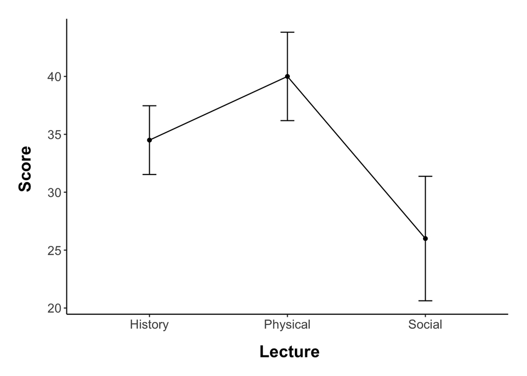

```r
# need to make the appropriate corrections for error bars on repeated measures designs:
normedData <- Rmisc::normDataWithin(data = example2_long,measurevar = "Score",idvar = "Subject")
nWithinGroups <- nlevels(example2_long$Lecture)
correctionFactor <- sqrt(nWithinGroups/(nWithinGroups - 1))


p <- ggplot(example2_long,mapping = aes(x = Lecture,y = Score, group=1)) +
  stat_summary(data = normedData,width=0.1, geom = "errorbar",fun.data = "mean_se", fun.args = list(mult = correctionFactor)) +
  stat_summary(geom = "point",fun.y = "mean") +
  stat_summary(geom = "line", fun.y="mean") + theme_classic() +
  #stat_summary(aes(label=..y..), fun.data="mean_se", geom="text", size=2) +
  theme(
    axis.title = element_text(size = 16, face = "bold", lineheight = .55),
    axis.text = element_text(size = 12),
    legend.title = element_text(size = 12, face = "bold"),
    legend.position = c(.25,.25)) +
  scale_color_manual(values=c("black","grey50")) +
  xlab("\n Lecture") +
  ylab ("Score \n") +
  theme(plot.margin=unit(c(.25,.25,.25,.25),"in")) +

  # stack legend boxes horizontally:
  theme(legend.box = "horizontal")

show(p)
```

## running the ANOVA:

```r
within.aov <- afex::aov_ez(id = "Subject", dv = "Score", data = example2_long,between = NULL,within = "Lecture",type = 3, return = "afex_aov", anova_table=list(es = "pes", correction="none",sig_symbols = rep("", 4)))
summary(within.aov)
```

```
##
## Univariate Type III Repeated-Measures ANOVA Assuming Sphericity
##
##                SS num Df Error SS den Df       F    Pr(>F)
## (Intercept) 40401      1   3531.7     11 125.836 2.319e-07 ***
## Lecture      1194      2   1067.3     22  12.305  0.000259 ***
## ---
## Signif. codes:  0 '***' 0.001 '**' 0.01 '*' 0.05 '.' 0.1 ' ' 1
##
##
## Mauchly Tests for Sphericity
##
##         Test statistic  p-value
## Lecture        0.41524 0.012345
##
##
## Greenhouse-Geisser and Huynh-Feldt Corrections
##  for Departure from Sphericity
##
##          GG eps Pr(>F[GG])
## Lecture 0.63101    0.00225 **
## ---
## Signif. codes:  0 '***' 0.001 '**' 0.01 '*' 0.05 '.' 0.1 ' ' 1
##
##            HF eps Pr(>F[HF])
## Lecture 0.6748954 0.00173583
```

You’ll notice that in this example the data failed Mauchly Tests for Sphericity. As I mentioned above in this case you’ll need to make the appropriate corrections. GG corrections are the “industry standard” (that is, I typically see these). HF corrections are note as conservative, and are appropriate in instances where the GG eps > 0.75. In this case we’ll use the GG correction. My advice, just rerun the ANOVA with `correction="GG"`:

```r
within.aov <- afex::aov_ez(id = "Subject", dv = "Score", data = example2_long,between = NULL,within = "Lecture",type = 3, return = "afex_aov", anova_table=list(es = "pes", correction="GG",sig_symbols = rep("", 4)))

within.aov
```

```
## Anova Table (Type 3 tests)
##
## Response: Score
##    Effect          df   MSE     F pes p.value
## 1 Lecture 1.26, 13.88 76.88 12.31 .53    .002
##
## Sphericity correction method: GG
```

## and our post-hoc tests…

```r
pairwise.t.test(example2_long$Score,example2_long$Lecture,p.adjust.method = "bonferroni",pool.sd = F,paired = T)
```

```
##
##  Pairwise comparisons using paired t tests
##
## data:  example2_long$Score and example2_long$Lecture
##
##          History Physical
## Physical 0.0121  -
## Social   0.1119  0.0021
##
## P value adjustment method: bonferroni
```

# EXAMPLE 3

Let’s ramp-up the complexity. Here is a dataset testing Recall over three days as a function of depth of processing (Lo, Med, High). In this case we have 2 within factors. As in Example 1 our original dataset is in wide format, with each subject on a row: ## loading in the data:

```r
downloader::download(url="https://raw.githubusercontent.com/tehjespah/tehjespah.github.io/master/teaching/PSYC7014/datasets/ANOVA5_example3.xlsx", "ANOVA5_example3.xlsx")

example3 <- readxl::read_excel("ANOVA5_example3.xlsx", skip = 1)
example3
```

| n | High | Moderate | Low | High__1 | Moderate__1 | Low__1 | High__2 | Moderate__2 | Low__2 |
| --- | --- | --- | --- | --- | --- | --- | --- | --- | --- |
| 1 | 14 | 12 | 11 | 12 | 10 | 10 | 18 | 14 | 10 |
| 2 | 10 | 8 | 9 | 16 | 15 | 8 | 20 | 15 | 9 |
| 3 | 13 | 10 | 8 | 18 | 14 | 12 | 16 | 14 | 11 |
| 4 | 14 | 11 | 10 | 15 | 15 | 8 | 22 | 15 | 11 |
| 5 | 12 | 10 | 7 | 14 | 11 | 12 | 19 | 12 | 8 |
| 6 | 8 | 13 | 8 | 11 | 10 | 9 | 17 | 17 | 9 |
| 7 | 13 | 10 | 8 | 15 | 14 | 10 | 21 | 16 | 11 |
| 8 | 11 | 8 | 12 | 16 | 10 | 9 | 16 | 11 | 10 |
| 9 | 9 | 12 | 9 | 13 | 12 | 9 | 22 | 14 | 9 |
| 10 | 12 | 11 | 9 | 11 | 9 | 8 | 19 | 16 | 12 |

## data wrangling:

We dealt with this a few times already. But data wrangling for interacting factors can be a bit of a chore. As I’ve done before, my best advice is to number each column condition when gathering the data. Below I’m stacking columns 2:10 in my original frame, leaving the Subject column out. The result will be that the Subject column is repeated as necessary, the raw data values are stacked on top of one another, and next to that each is assigned a number indicating which column, or `Cell` it was originally in.

```r
# rename by column number
names(example3) <- c("Subject",1:(ncol(example3)-1))

# stack columns and assign names
example3_long <- gather(data=example3,key = "Cell",value = "Recalled",2:10)


example3_long$ProcessDepth <- rep(0,nrow(example3_long))
example3_long$Day <- rep(0,nrow(example3_long))
```

From here I can create new columns for `ProcessDepth` and `Day` based upon the `Cell` column number, resulting in an ideal long format frame.

```r
example3_long$ProcessDepth[example3_long$Cell %in% c(1,4,7)] <- "High"
example3_long$ProcessDepth[example3_long$Cell %in% c(2,5,8)] <- "Med"
example3_long$ProcessDepth[example3_long$Cell %in% c(3,6,9)] <- "Lo"

example3_long$Day[example3_long$Cell %in% c(1:3)] <- "Day1"
example3_long$Day[example3_long$Cell %in% c(4:6)] <- "Day2"
example3_long$Day[example3_long$Cell %in% c(7:9)] <- "Day3"

example3_long$ProcessDepth <-  as.factor(example3_long$ProcessDepth)
example3_long$Day <- as.factor(example3_long$Day)

summary(example3_long)
```

```
##     Subject         Cell              Recalled     ProcessDepth   Day
##  Min.   : 1.0   Length:90          Min.   : 7.00   High:30      Day1:30
##  1st Qu.: 3.0   Class :character   1st Qu.:10.00   Lo  :30      Day2:30
##  Median : 5.5   Mode  :character   Median :11.50   Med :30      Day3:30
##  Mean   : 5.5                      Mean   :12.24
##  3rd Qu.: 8.0                      3rd Qu.:14.00
##  Max.   :10.0                      Max.   :22.00
```

## plotting the data

Again, we need to make the appropriate correction for our error bars. In this case the number of within groups is the number of cells that is formed by crossing Day (1,2,3) and Processing Depth (Lo, Med, Hi). As this is a 3 * 3 design there are 9 cells, or `nWithinGroups=9`

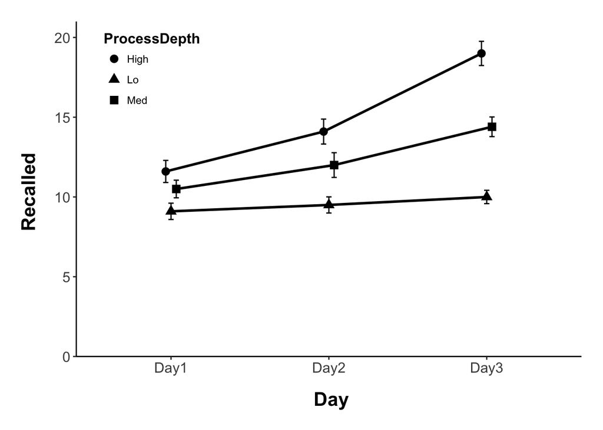

```r
# need to make the appropriate corrections for error bars on repeated measures designs:

normedData <- Rmisc::normDataWithin(data = example3_long,measurevar = "Recalled",idvar = "Subject")

nWithinGroups <- nlevels(example3_long$ProcessDepth) * nlevels(example3_long$Day)

correctionFactor <- sqrt(nWithinGroups/(nWithinGroups - 1))

p <- ggplot(example3_long,mapping = aes(x = Day,y = Recalled, group=ProcessDepth)) +
    stat_summary(data = normedData, geom = "errorbar",fun.data = "mean_cl_normal", width = .1, color = "black", position = position_dodge(.1), fun.args = list(mult = correctionFactor)) +
  stat_summary(geom = "point",fun.y = "mean", size = 3, fill = "black", aes(shape=ProcessDepth), position = position_dodge(.1)) +
  stat_summary(geom = "line",fun.y = "mean", size = 1, color = "black", aes(shape=ProcessDepth), position = position_dodge(.1)) +
  theme_classic() + theme(
    axis.title = element_text(size = 16, face = "bold", lineheight = .55),
    axis.text = element_text(size = 12),
    legend.title = element_text(size = 12, face = "bold"),
    legend.position = c(.15,.85)) +
  scale_y_continuous(expand = c(0,0)) +
  expand_limits(y=c(0,21)) +
  xlab("\n Day") +
  ylab ("Recalled \n") +
  theme(plot.margin=unit(c(.25,.25,.25,.25),"in")) +

  # stack legend boxes horizontally:
  theme(legend.box = "horizontal")
show(p)
```

## running the omnibus ANOVA:

```r
omnibus.aov <- afex::aov_ez(id = "Subject", dv = "Recalled", data = example3_long,between = NULL,within = c("ProcessDepth","Day"),type = 3, return = "afex_aov", anova_table=list(es = "pes", correction="none",sig_symbols = rep("", 4)))

summary(omnibus.aov)
```

```
##
## Univariate Type III Repeated-Measures ANOVA Assuming Sphericity
##
##                       SS num Df Error SS den Df        F    Pr(>F)
## (Intercept)      13493.4      1   41.067      9 2957.153 1.209e-12 ***
## ProcessDepth       432.2      2   61.400     18   63.345 7.137e-09 ***
## Day                254.5      2   95.733     18   23.925 8.521e-06 ***
## ProcessDepth:Day   110.4      4   93.400     36   10.636 8.567e-06 ***
## ---
## Signif. codes:  0 '***' 0.001 '**' 0.01 '*' 0.05 '.' 0.1 ' ' 1
##
##
## Mauchly Tests for Sphericity
##
##                  Test statistic p-value
## ProcessDepth            0.94884 0.81054
## Day                     0.81573 0.44277
## ProcessDepth:Day        0.22026 0.27277
##
##
## Greenhouse-Geisser and Huynh-Feldt Corrections
##  for Departure from Sphericity
##
##                   GG eps Pr(>F[GG])
## ProcessDepth     0.95133  1.559e-08 ***
## Day              0.84440  3.539e-05 ***
## ProcessDepth:Day 0.71617  0.0001178 ***
## ---
## Signif. codes:  0 '***' 0.001 '**' 0.01 '*' 0.05 '.' 0.1 ' ' 1
##
##                    HF eps   Pr(>F[HF])
## ProcessDepth     1.199509 7.136593e-09
## Day              1.018163 8.520701e-06
## ProcessDepth:Day 1.085791 8.566883e-06
```

Here we got two main effects and an interaction. Let’s unpack the interaction by taking a look at whether Recall inceases over sucessive days.

## running the simple effects ANOVAs

```r
hi.data <- subset(example3_long, ProcessDepth=="High")
med.data <- subset(example3_long, ProcessDepth=="Med")
lo.data <- subset(example3_long, ProcessDepth=="Lo")

hi.aov <- afex::aov_ez(id = "Subject", dv = "Recalled", data = hi.data,between = NULL,within = "Day",type = 3, return = "afex_aov", anova_table=list(es = "pes", correction="none",sig_symbols = rep("", 4)))

hi.aov
```

```
## Anova Table (Type 3 tests)
##
## Response: Recalled
##   Effect    df  MSE     F pes p.value
## 1    Day 2, 18 4.59 30.88 .77  <.0001
```

```r
pairwise.t.test(hi.data$Recalled,g = hi.data$Day, p.adjust.method = "bonferroni",paired = T,pool.sd = F)
```

```
##
##  Pairwise comparisons using paired t tests
##
## data:  hi.data$Recalled and hi.data$Day
##
##      Day1    Day2
## Day2 0.0449  -
## Day3 7.1e-05 0.0045
##
## P value adjustment method: bonferroni
```

```r
med.aov <- afex::aov_ez(id = "Subject", dv = "Recalled", data = med.data,between = NULL,within = "Day",type = 3, return = "afex_aov", anova_table=list(es = "pes", correction="none",sig_symbols = rep("", 4)))

med.aov
```

```
## Anova Table (Type 3 tests)
##
## Response: Recalled
##   Effect    df  MSE     F pes p.value
## 1    Day 2, 18 3.51 11.01 .55   .0008
```

```r
pairwise.t.test(med.data$Recalled,g = med.data$Day, p.adjust.method = "bonferroni",paired = T,pool.sd = F)
```

```
##
##  Pairwise comparisons using paired t tests
##
## data:  med.data$Recalled and med.data$Day
##
##      Day1    Day2
## Day2 0.54413 -
## Day3 0.00016 0.06274
##
## P value adjustment method: bonferroni
```

```r
lo.aov <- afex::aov_ez(id = "Subject", dv = "Recalled", data = lo.data,between = NULL,within = "Day",type = 3, return = "afex_aov", anova_table=list(es = "pes", correction="none",sig_symbols = rep("", 4)))

lo.aov
```

```
## Anova Table (Type 3 tests)
##
## Response: Recalled
##   Effect    df  MSE    F pes p.value
## 1    Day 2, 18 2.40 0.85 .09     .45
```

```r
pairwise.t.test(lo.data$Recalled,g = lo.data$Day, p.adjust.method = "bonferroni",paired = T,pool.sd = F)
```

```
##
##  Pairwise comparisons using paired t tests
##
## data:  lo.data$Recalled and lo.data$Day
##
##      Day1 Day2
## Day2 1.0  -
## Day3 0.4  1.0
##
## P value adjustment method: bonferroni
```

# Multiple Trials ??

Every example that we have considered to this point have 1 data point per subject per condition. This would be the case if (a) we only took one sample per subject per condition, or (b) the values represent mean values taken from a number of trials. In experimental research, the latter is more likely the case—that your original data set included multiple trials. For example, in perception / cognitive research it is quite common to collect 2,3,4 or more trials per condition. This increases the relative power of your experiment and also helps to attenuate the effects of any outlier trial. That is you use each additional trial to ensure that your measure is indeed reliable and not some one-off.

That said, there are potential issues for how one goes about conducting ANOVA for instances were multiple data points were taken per participant per condition. For example SPSS only takes 1 line per subject. So when conducting ANOVA in SPSS that involves multiple trials per condition you need to do some pre-processing to reduce thoe multiple trials to a single value (typically the mean). That, or you could include trial as an additional within-factor. People typically choose the former. In R, `afex` performs this process for you as long as you have your subjects properly labelled.

# How to perform a within subjects analysis in SPSS:

I’ll likely but together my own vid, but it won’t be much better than this:

https://www.youtube.com/watch?v=9TDvejlOP0Q